# xwMOOC 모형

캐글 - 전자상거래 옷 리뷰

xwMOOC

Tidyverse Korea

2018-11-26

# 1 캐글 데이터셋

[Women’s e-commerce cloting reviews](https://www.kaggle.com/nicapotato/womens-ecommerce-clothing-reviews) 데이터를 바탕으로 텍스트 데이터를 예측모형에 Feature로 넣어 예측력을 향상시키는 방안을 살펴보자.

현장에서 자연어 처리(NLP)는 매우 드물지만 텍스트 데이터에 대한 중요도는 지속적으로 증대되고 있다. 이를 현재 시점에서 대응하는 한 방식이 깔끔한 데이터(Tidy Data) 원칙을 단순히 단어를 세는 Count-based 방법론과 결합하면 상당히 실무에서 유용하게 활용할 수 있게 된다.

## 1.1 데이터 사전

- Clothing ID: Integer Categorical variable that refers to the specific piece being reviewed.
- Age: Positive Integer variable of the reviewers age.
- Title: String variable for the title of the review.
- Review Text: String variable for the review body.
- Rating: Positive Ordinal Integer variable for the product score granted by the customer from 1 Worst, to 5 Best.
- Recommended IND: Binary variable stating where the customer recommends the product where 1 is recommended, 0 is not - recommended.
- Positive Feedback Count: Positive Integer documenting the number of other customers who found this review positive.
- Division Name: Categorical name of the product high level division.
- Department Name: Categorical name of the product department name.
- Class Name: Categorical name of the product class name.

```r
library(tidyverse)
library(janitor)

cloth_dat <- read_csv("data/Womens Clothing E-Commerce Reviews.csv")
```

## 1.2 데이터 전처리

캐글 옷 리뷰 데이터에서 텍스트 관련 변수(`Title`, `Review`)를 따로 빼서 직사각형 데이터프레임을 생성한다. 즉, 텍스트는 별도로 빼서 **DTM**을 만들어 결합시킨다. 텍스트 Feature를 모형설계행렬로 반영한 후 예측모형 알고리즘을 돌려 예측모형 정확도를 향상시킨다.

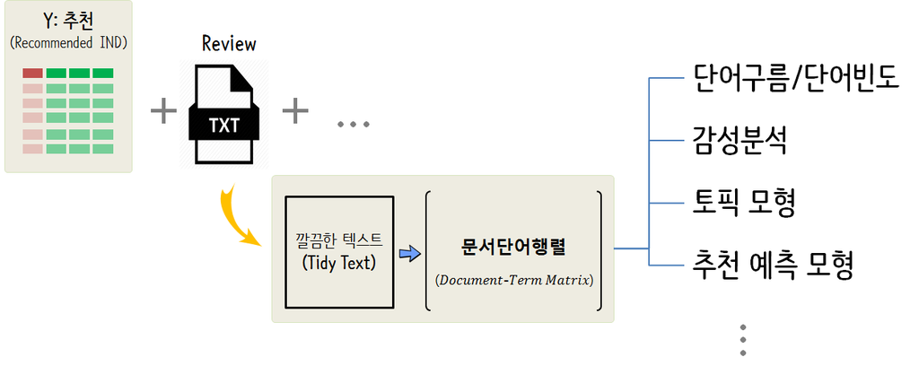

```r
cloth_dat <- cloth_dat %>%
  clean_names() %>%
  filter(complete.cases(.)) %>%
  rename(y = recommended_ind)

cloth_df <- cloth_dat %>%
  mutate(y = factor(y, levels=c(1,0), labels=c("yes", "no"))) %>%
  mutate_if(is.character, as.factor) %>%
  select(y, age, title, review_text, division_name, department_name, class_name) %>%
  mutate(class = fct_lump(class_name, 9)) %>%
  mutate(review = str_c(title, " ", review_text)) %>%
  select(y, age, division = division_name, department = department_name, class, review) %>%
  mutate(review_id = row_number())

cloth_text_df <- cloth_df %>%
  select(review_id, review)

cloth_text_df %>%
  sample_n(10) %>%
  DT::datatable()
```

|  | review_id | review |
| --- | --- | --- |
| 1 | 19246 | Quality and style strange I liked this top, i really did. i also liked the subtle shimmer. the fabric didn't seem as soft, but i could not get over the big difference in length between the front and t… |
| 2 | 3617 | Classy and good quality! I have never purchased this brand before at retailer and there were no reviews on it when i purchased it. i bought my usual size medium and it fit perfectly! i am 5'2", 120# w… |
| 3 | 10802 | Cutest cape!!! This arrived in my store this morning and it is as cute as it appears online!! i'm a curvy gal so i honestly wasn't feeling like this would look good on me. but it is thick and the fabr… |
| 4 | 3169 | Cute and stylish This is a nice looking skirt. the corduroy has a little sheen to it. looks cute with a sweater, tights and boots. length is slightly longer on me than the model in the photo. there ar… |
| 5 | 11915 | Beautiful, but slip is small I ordered this in a size 4 and it is great quality. the only problem is the size of the slip. the top is very tight across my average chest, but fine elsewhere - odd fit. … |
| 6 | 8392 | Great dress, but not my style I am sadly returning this dress, but i would recommend it! it is soft and i loved the design of the dress. very comfortable. the only reason i am returning it is due to m… |
| 7 | 1091 | Soft lightweight and cool This tee is super soft and thin. perfect for hot humid days. i went with the neutral version and it is adorable with chino shorts or jean shorts. i found it ran big.. i purch… |
| 8 | 4515 | A keeper! Ok you had me at the western scene. soft and comfortable. true to size. you can dress it up or down. just a great t shirt. recommend it! get it!! |
| 9 | 17418 | So wanted to love it I so wanted to love this dress, despite the reviews. when i opened the package i fell in love with the fabric. the print is absolutely beautiful and the fabric feels luxurious. th… |
| 10 | 9660 | So nice for fall I decided to order this skirt to look at it and regret it now as i want to keep it. one bummer is the smallest size (xs) runs big, the skirt falls on my lower waist aka hips on me, no… |

## 1.3 깔끔한 텍스트 데이터 [^1]

원본 텍스트 데이터를 `unnest_tokens()` 함수로 깔끔한 텍스트 형태로 변환시킨다. 그리고 나서 불용어 사전에서 불용어를 `anti_join()`으로 제거한다.

```r
library(tidytext)

cloth_tidytext_df <- cloth_text_df %>%
  unnest_tokens(word, review) %>%
  anti_join(get_stopwords(source = "smart"))

cloth_tidytext_df %>%
  sample_n(100) %>%
  DT::datatable()
```

|  | review_id | word |
| --- | --- | --- |
| 1 | 1327 | substantial |
| 2 | 5906 | tee |
| 3 | 15924 | arms |
| 4 | 17745 | part |
| 5 | 2061 | mild |
| 6 | 4876 | thought |
| 7 | 4476 | wore |
| 8 | 14256 | super |
| 9 | 15526 | pockets |
| 10 | 7599 | belly |

[output cut: 90 more lines]

# 2 텍스트 기술통계량

## 2.1 추천 비추천 감성분석

### 2.1.1 추천 비추천 고빈도 단어

추천과 비추천에 많이 사용된 단어를 상위 10개 뽑아 비교한다.

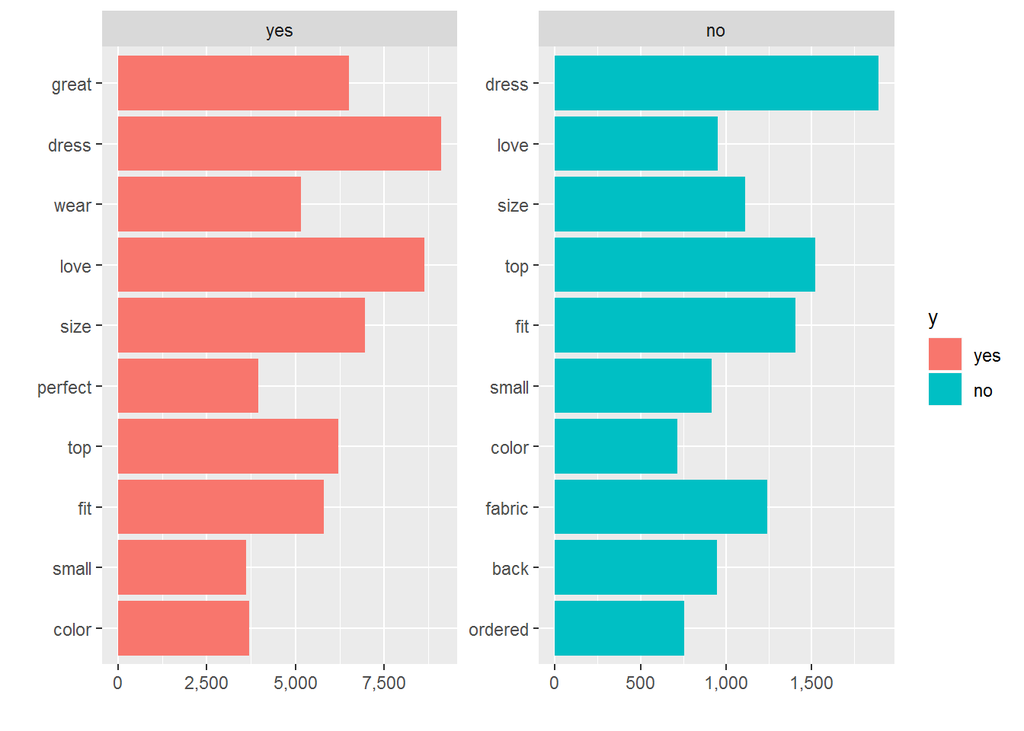

```r
cloth_df %>%
  select(review_id, y) %>%
  left_join(cloth_tidytext_df) %>%
    count(word, y, sort=TRUE) %>%
    group_by(y) %>%
    top_n(10, wt=n) %>%
    ungroup() %>%
    ggplot(aes(x = fct_reorder(word, n), y=n, fill=y)) +
      geom_col() +
      coord_flip() +
      facet_wrap(~y, scales = "free") +
      labs(x="", y="") +
      scale_y_continuous(labels = scales::comma)
```

### 2.1.2 긍부정 감성 고빈도 단어

옷추천과 비추천을 감성분석과 연계하여 추천에 활용된 긍정적인 단어와 비추천에 활용도가 높은 단어 빈도수를 비교한다.

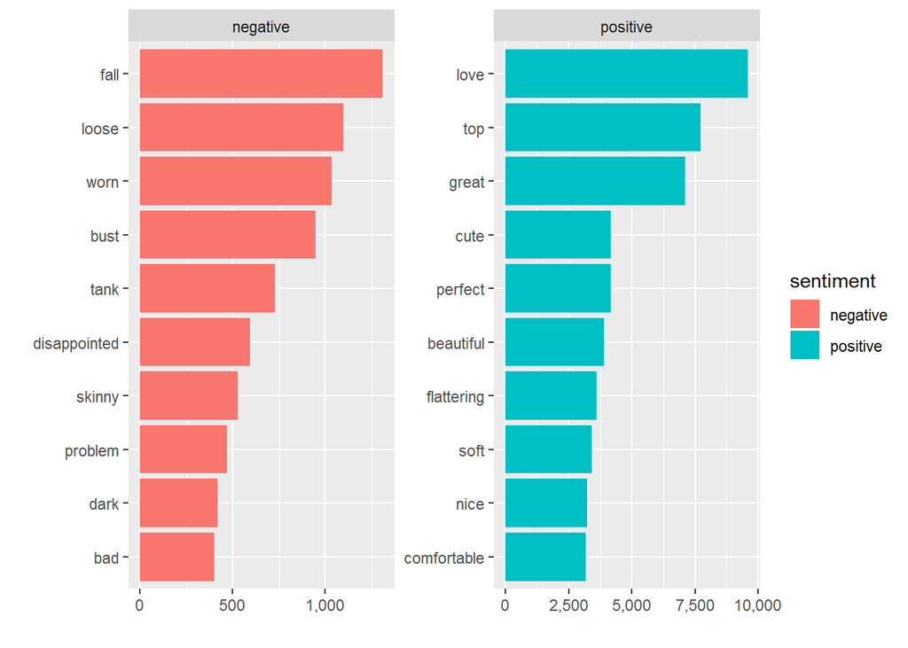

```r
cloth_tidytext_df %>%
  inner_join(get_sentiments("bing")) %>%
  count(word, sentiment, sort=TRUE) %>%
  group_by(sentiment) %>%
  top_n(10, wt=n) %>%
  ungroup() %>%
  ggplot(aes(x=reorder(word,n), y=n, fill=sentiment)) +
    geom_col() +
    coord_flip() +
    facet_wrap(~sentiment, scales = "free") +
    labs(x="", y="") +
    scale_y_continuous(labels = scales::comma)
```

리뷰에 나타난 전체를 파악하는 대신에, 추천과 비추천 리뷰에 동원된 감성어도 각기 나눠 살펴볼 수 있다. 이를 위해서 `review_id`를 추천여부와 결합하여 감성분석결과와 결합하여 구분필드로 활용한다.

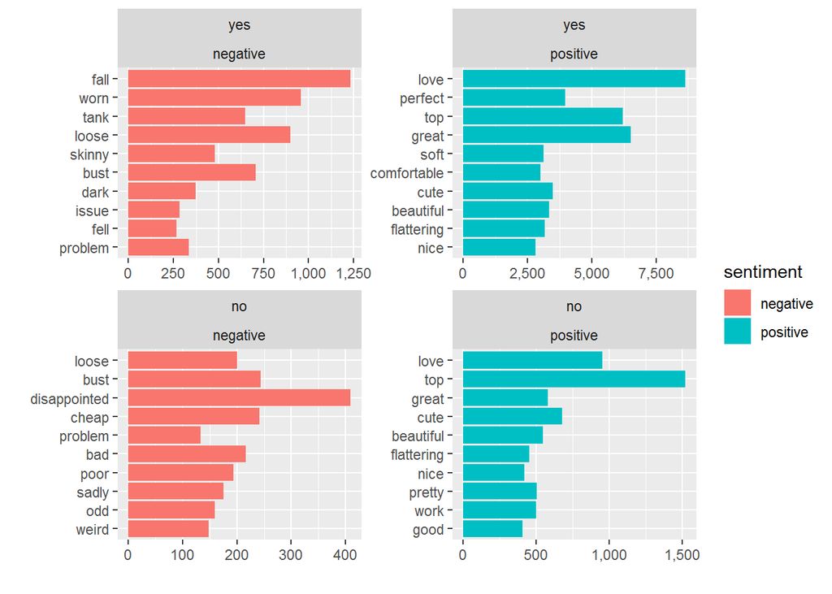

```r
cloth_df %>%
  select(review_id, y) %>%
  left_join(cloth_tidytext_df) %>%
    inner_join(get_sentiments("bing")) %>%
    count(y, word, sentiment, sort=TRUE) %>%
    group_by(y, sentiment) %>%
    top_n(10, wt=n) %>%
    ungroup() %>%
    ggplot(aes(x=fct_reorder(word, n), y=n, fill=sentiment)) +
      geom_col() +
      coord_flip() +
      facet_wrap(~y+sentiment, scales = "free") +
      labs(x="", y="") +
      scale_y_continuous(labels = scales::comma)
```

# 3 리뷰 중요단어 - `tf-idf`

`tf-idf`는 옷리뷰에 대한 추천과 비추천 분석에 대한 중요지표가 된다. `bind_tf_idf()` 함수로 추천과 비추천 리뷰에 대한 중요단어를 추출하여 막대그래프로 시각화한다.

```r
## 리뷰 전체 단어숫자
review_words <- cloth_tidytext_df %>%
  count(review_id, word, sort = TRUE)

total_review_words <- review_words %>%
 group_by(review_id) %>%
 summarize(total = sum(n))

## 리뷰 TF-IDF
cloth_tidytext_tfidf <- cloth_tidytext_df %>%
  count(review_id, word) %>%
  left_join(total_review_words) %>%
  bind_tf_idf(word, review_id, n)

cloth_tidytext_tfidf %>%
  top_n(100, wt=tf_idf) %>%
  arrange(desc(tf_idf)) %>%
  DT::datatable() %>%
    DT::formatRound(c(5:7), digits=3)
```

|  | review_id | word | n | total | tf | idf | tf_idf |
| --- | --- | --- | --- | --- | --- | --- | --- |
| 1 | 18497 | ribbed | 3 | 5 | 0.6 | 6.30292417947076 | 3.78175450768246 |
| 2 | 7206 | bend | 1 | 2 | 0.5 | 6.62834657990539 | 3.31417328995269 |
| 3 | 13289 | cover | 2 | 3 | 0.666666666666667 | 4.54890503822555 | 3.03260335881703 |
| 4 | 10647 | skinnier | 2 | 6 | 0.333333333333333 | 8.27700520549277 | 2.75900173516426 |
| 5 | 19601 | quick | 2 | 5 | 0.4 | 6.45245591344172 | 2.58098236537669 |
| 6 | 15394 | short | 1 | 1 | 1 | 2.51621247611979 | 2.51621247611979 |
| 7 | 617 | scratchy | 2 | 4 | 0.5 | 4.98116833948844 | 2.49058416974422 |
| 8 | 5337 | favorite.it | 1 | 4 | 0.25 | 9.88644311792687 | 2.47161077948172 |
| 9 | 5337 | priceless | 1 | 4 | 0.25 | 9.19329593736692 | 2.29832398434173 |
| 10 | 7206 | totally | 1 | 2 | 0.5 | 4.44836380900367 | 2.22418190450184 |

[output cut: 90 more lines]

`cloth_df` 에서 추천/비추천 필드(`y`)를 결합해서 앞서 계산한 `tf_idf`와 결합하여 해당 리뷰에서는 자주 나타나고, 전체 리뷰에는 적게 나타나는 단어를, 추천/비추천과 결합하여 중요한 단어를 식별해 낸다.

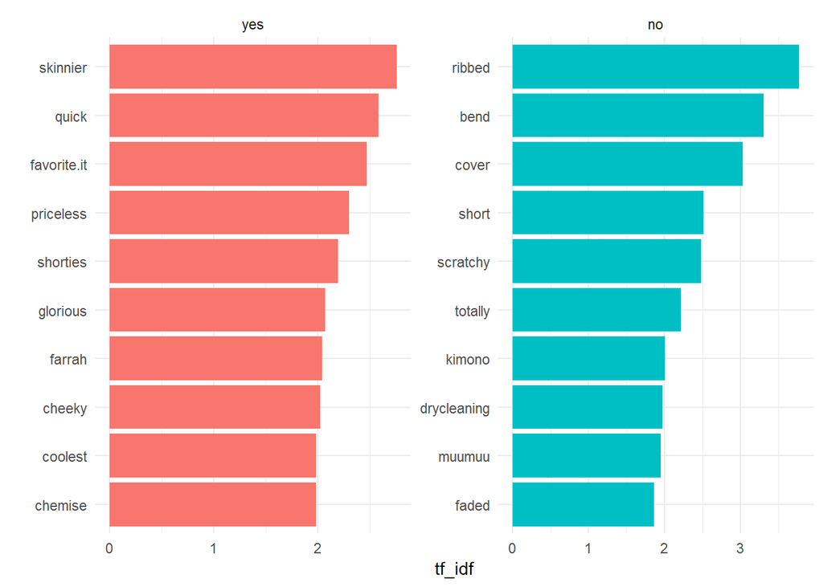

```r
cloth_df %>%
  select(review_id, y) %>%
  left_join(cloth_tidytext_tfidf) %>%
    group_by(y) %>%
    top_n(10, wt=tf_idf) %>%
    ungroup() %>%
  ggplot(aes(fct_reorder(word, tf_idf), tf_idf, fill = y)) +
    geom_col(show.legend = FALSE) +
    coord_flip() +
    facet_wrap(~y, scales = "free") +
    theme_minimal() +
    labs(x="")
```